# My Activities in 2018 with R

John Letteboer

3 January 2019

What better way to analyze your activities data from Apple Health and Runkeeper into R and generating some visualizations and counters. After that I will wrapping it together into a Shiny App.

Want do I want to achieve for now?

- Number of activities, steps, kilometers ect.
- Heatmap of last X years number of activities colored by amount.

## Loading and have a look at the data

Export Runkeeper data, the option is available after login > account settings > export data > download your data.

For export and convert your Apple Health data follow my previous post [Analysing your Apple Health Data with Splunk](http://www.networkx.nl/data-science/visualising-health-data/).

```r
runkeeper <- read.csv("data/cardioActivities.csv", stringsAsFactors=FALSE)
steps <- read.csv("data/StepCount.csv", stringsAsFactors = FALSE)
dim(runkeeper)
```

```
## [1] 676  14
```

```r
dim(steps)
```

```
## [1] 47790     9
```

```r
head(runkeeper)
```

```
##                            Activity.Id                Date         Type
## 1 47f59049-9bd5-4b9a-a63c-d51fca7e0bf8 2018-12-31 10:22:33      Running
## 2 7099bd74-7685-453e-a962-62ee711dc18e 2018-12-27 20:24:09      Running
## 3 c2250f5b-8567-47ef-97d7-504b174809e1 2018-12-23 13:28:04      Running
## 4 787c8438-d279-49fb-8bab-d1f348935264 2018-12-18 21:07:42 Boxing / MMA
## 5 2c41d494-204b-4be3-9b4e-d7acac5a3187 2018-12-16 13:04:44      Running
## 6 86b6429a-13a8-4122-b200-c3aadef271f5 2018-12-04 20:24:27 Boxing / MMA
##   Route.Name Distance..km. Duration Average.Pace Average.Speed..km.h.
## 1                     8.12    50:49         6:15                 9.59
## 2                    15.99  1:27:36         5:29                10.95
## 3                     8.31    50:04         6:01                 9.96
## 4                     0.00  1:20:00                                NA
## 5                    10.51    56:47         5:24                11.10
## 6                     0.00  1:00:00                                NA
##   Calories.Burned Climb..m. Average.Heart.Rate..bpm. Friend.s.Tagged Notes
## 1           772.0        83                      134
## 2          1485.0        57                      147
## 3           788.0        88                      134
## 4          1032.4         0                       NA
## 5           979.0        41                      145
## 6           774.3         0                       NA
##                GPX.File
## 1 2018-12-31-102233.gpx
## 2 2018-12-27-202409.gpx
## 3 2018-12-23-132804.gpx
## 4
## 5 2018-12-16-130444.gpx
## 6
```

```r
head(steps)
```

```
##      sourceName sourceVersion
## 1 John’s iPhone        10.1.1
## 2 John’s iPhone        10.1.1
## 3 John’s iPhone        10.1.1
## 4 John’s iPhone        10.1.1
## 5 John’s iPhone        10.1.1
## 6 John’s iPhone        10.1.1
##                                                                                                          device
## 1 <<HKDevice: 0x2836d9310>, name:iPhone, manufacturer:Apple, model:iPhone, hardware:iPhone8,1, software:10.1.1>
## 2 <<HKDevice: 0x2836db070>, name:iPhone, manufacturer:Apple, model:iPhone, hardware:iPhone8,1, software:10.1.1>
## 3 <<HKDevice: 0x2836d9d10>, name:iPhone, manufacturer:Apple, model:iPhone, hardware:iPhone8,1, software:10.1.1>
## 4 <<HKDevice: 0x2836dad50>, name:iPhone, manufacturer:Apple, model:iPhone, hardware:iPhone8,1, software:10.1.1>
## 5 <<HKDevice: 0x2836da080>, name:iPhone, manufacturer:Apple, model:iPhone, hardware:iPhone8,1, software:10.1.1>
## 6 <<HKDevice: 0x2836dabc0>, name:iPhone, manufacturer:Apple, model:iPhone, hardware:iPhone8,1, software:10.1.1>
##        type  unit              creationDate                 startDate
## 1 StepCount count 2016-11-24 09:13:55 +0100 2016-11-24 08:55:10 +0100
## 2 StepCount count 2016-11-24 09:13:55 +0100 2016-11-24 09:10:09 +0100
## 3 StepCount count 2016-11-24 09:13:55 +0100 2016-11-24 09:11:11 +0100
## 4 StepCount count 2016-11-24 09:13:55 +0100 2016-11-24 09:12:13 +0100
## 5 StepCount count 2016-11-24 09:49:04 +0100 2016-11-24 09:13:19 +0100
## 6 StepCount count 2016-11-24 09:49:04 +0100 2016-11-24 09:33:57 +0100
##                     endDate value
## 1 2016-11-24 08:55:33 +0100    26
## 2 2016-11-24 09:11:11 +0100   114
## 3 2016-11-24 09:12:13 +0100   105
## 4 2016-11-24 09:13:19 +0100    25
## 5 2016-11-24 09:22:42 +0100   108
## 6 2016-11-24 09:42:33 +0100    89
```

```r
str(runkeeper)
```

```
## 'data.frame':    676 obs. of  14 variables:
##  $ Activity.Id             : chr  "47f59049-9bd5-4b9a-a63c-d51fca7e0bf8" "7099bd74-7685-453e-a962-62ee711dc18e" "c2250f5b-8567-47ef-97d7-504b174809e1" "787c8438-d279-49fb-8bab-d1f348935264" ...
##  $ Date                    : chr  "2018-12-31 10:22:33" "2018-12-27 20:24:09" "2018-12-23 13:28:04" "2018-12-18 21:07:42" ...
##  $ Type                    : chr  "Running" "Running" "Running" "Boxing / MMA" ...
##  $ Route.Name              : chr  "" "" "" "" ...
##  $ Distance..km.           : num  8.12 15.99 8.31 0 10.51 ...
##  $ Duration                : chr  "50:49" "1:27:36" "50:04" "1:20:00" ...
##  $ Average.Pace            : chr  "6:15" "5:29" "6:01" "" ...
##  $ Average.Speed..km.h.    : num  9.59 10.95 9.96 NA 11.1 ...
##  $ Calories.Burned         : num  772 1485 788 1032 979 ...
##  $ Climb..m.               : int  83 57 88 0 41 0 62 0 0 0 ...
##  $ Average.Heart.Rate..bpm.: int  134 147 134 NA 145 NA 145 NA NA NA ...
##  $ Friend.s.Tagged         : chr  "" "" "" "" ...
##  $ Notes                   : chr  "" "" "" "" ...
##  $ GPX.File                : chr  "2018-12-31-102233.gpx" "2018-12-27-202409.gpx" "2018-12-23-132804.gpx" "" ...
```

```r
str(steps)
```

```
## 'data.frame':    47790 obs. of  9 variables:
##  $ sourceName   : chr  "John’s iPhone" "John’s iPhone" "John’s iPhone" "John’s iPhone" ...
##  $ sourceVersion: chr  "10.1.1" "10.1.1" "10.1.1" "10.1.1" ...
##  $ device       : chr  "<<HKDevice: 0x2836d9310>, name:iPhone, manufacturer:Apple, model:iPhone, hardware:iPhone8,1, software:10.1.1>" "<<HKDevice: 0x2836db070>, name:iPhone, manufacturer:Apple, model:iPhone, hardware:iPhone8,1, software:10.1.1>" "<<HKDevice: 0x2836d9d10>, name:iPhone, manufactur…
##  $ type         : chr  "StepCount" "StepCount" "StepCount" "StepCount" ...
##  $ unit         : chr  "count" "count" "count" "count" ...
##  $ creationDate : chr  "2016-11-24 09:13:55 +0100" "2016-11-24 09:13:55 +0100" "2016-11-24 09:13:55 +0100" "2016-11-24 09:13:55 +0100" ...
##  $ startDate    : chr  "2016-11-24 08:55:10 +0100" "2016-11-24 09:10:09 +0100" "2016-11-24 09:11:11 +0100" "2016-11-24 09:12:13 +0100" ...
##  $ endDate      : chr  "2016-11-24 08:55:33 +0100" "2016-11-24 09:11:11 +0100" "2016-11-24 09:12:13 +0100" "2016-11-24 09:13:19 +0100" ...
##  $ value        : int  26 114 105 25 108 89 329 284 89 18 ...
```

From the Runkeeper data we need `Date` and from Apple Health StepCount we need the `endDate` (thats when your step is done). Both has type `chr`. I could convert it as date, but I leave the data what it is and will do convert it when necessary.

## Create new variables

First we load the `lubridate` package.

```r
library(lubridate)
```

I will create some new variables and convert `Date` and `endDate` as Date so I can extract the year with the `year` function of the `lubridate` package.

```r
runkeeper$year <- year(as.Date(runkeeper$Date, origin = '1900-01-01'))
steps$year <- year(as.Date(steps$endDate, origin = '1900-01-01'))
summary(runkeeper$year)
```

```
##    Min. 1st Qu.  Median    Mean 3rd Qu.    Max.
##    2010    2013    2016    2015    2017    2018
```

```r
summary(steps$year)
```

```
##    Min. 1st Qu.  Median    Mean 3rd Qu.    Max.
##    2016    2017    2017    2017    2018    2019
```

As you can see in the above summary of both dataframes, Runkeeper has more years than steps. That doesn’t matter becouse we are now only looking for 2018 in the Shiny App and I will group it by year. In the app I create a year slider.

I will parse the period with hour, minuts ans seconds of the variable `Duration`. And I will calculate the duration in minutus. Some of the `Duration` variables has no leading zero for the hour and I cannot use it with the function `hms`.

Add a leading zero if not exists.

```r
runkeeper$Duration[1:5]
```

```
## [1] "50:49"   "1:27:36" "50:04"   "1:20:00" "56:47"
```

```r
runkeeper$Duration <- ifelse(nchar(runkeeper$Duration) < 6,
                             paste0("0:", runkeeper$Duration), runkeeper$Duration)
runkeeper$Duration[1:5]
```

```
## [1] "0:50:49" "1:27:36" "0:50:04" "1:20:00" "0:56:47"
```

Now I can parse the `Duration` with `hms`.

```r
runkeeper$lub <- hms(runkeeper$Duration)
runkeeper$time_minutes <- hour(runkeeper$lub)*60 +
  minute(runkeeper$lub) +
  second(runkeeper$lub)/60
runkeeper$lub[1:5]
```

```
## [1] "50M 49S"    "1H 27M 36S" "50M 4S"     "1H 20M 0S"  "56M 47S"
```

```r
runkeeper$time_minutes[1:5]
```

```
## [1] 50.81667 87.60000 50.06667 80.00000 56.78333
```

## Group the data by year

First we load the package `dplyr`.

```r
library(dplyr)
```

Group both dataframes by year and do some summarises like count and sum of kilometers, climb, calories and duration

```r
grouped_runkeeper_year <- runkeeper %>%
  group_by(year) %>%
  summarise(cnt = n(),
            km = sum(Distance..km.),
            climb = sum(Climb..m.),
            calories = sum(Calories.Burned),
            duration = sum(time_minutes, na.rm = TRUE))

grouped_steps_year <- steps %>%
  group_by(year) %>%
  summarise(cnt = sum(value))

grouped_runkeeper_year
```

```
## # A tibble: 9 x 6
##    year   cnt     km climb calories duration
##   <dbl> <int>  <dbl> <int>    <dbl>    <dbl>
## 1  2010     3   10.8     0     901      71.8
## 2  2011    96  657.   1951   56333    3864.
## 3  2012    46  410.   1458   36876    2278.
## 4  2013    46  258.    488   22654    1456.
## 5  2014    24  175.    698   14382     992.
## 6  2015   117 1202.   5910   98518    7537.
## 7  2016    93  661.   3076   65275.   5397.
## 8  2017   128  408.   1569   89872.   7404.
## 9  2018   123  366.   1818   86792.   7062.
```

```r
grouped_steps_year
```

```
## # A tibble: 4 x 2
##    year     cnt
##   <dbl>   <int>
## 1  2016  328759
## 2  2017 3360951
## 3  2018 4366289
## 4  2019    3692
```

## Some simple visualizations

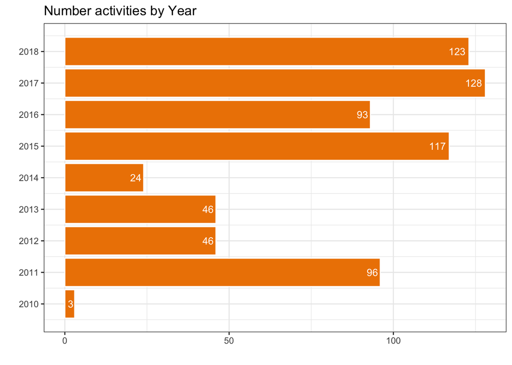

```r
library(ggplot2)
library(RColorBrewer)
grouped_runkeeper_year %>%
  ggplot(aes(x=year, y=cnt )) +
  geom_bar(stat = "identity", col="white", fill="#ee8300") +
  geom_text(aes(label=cnt), hjust=1.2, color="white", size=3.5) +
  labs(x="", y="", title="Number activities by Year") +
  scale_x_continuous(breaks=seq(min(grouped_runkeeper_year$year),
                                max(grouped_runkeeper_year$year),1)) +
  coord_flip() +
  theme_bw()
```

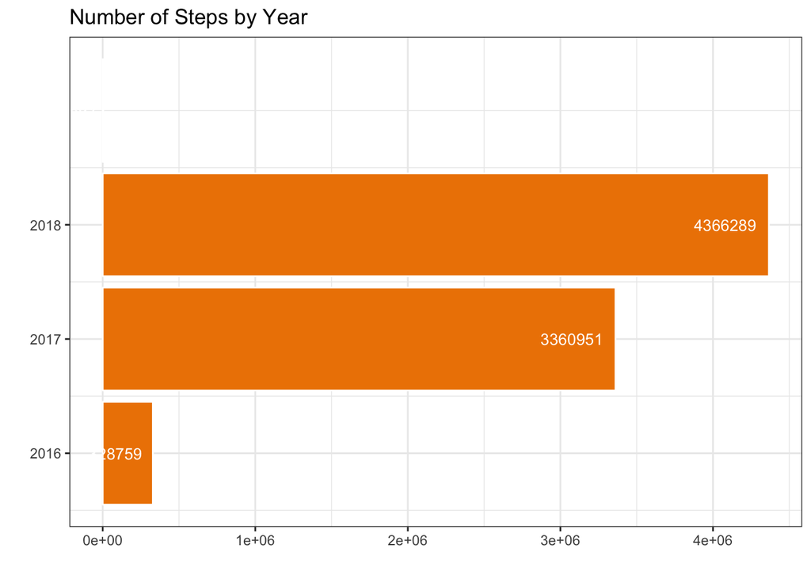

```r
grouped_steps_year %>%
  ggplot(aes(x=year, y=cnt )) +
  geom_bar(stat = "identity", col="white", fill="#ee8300") +
  geom_text(aes(label=cnt), hjust=1.2, color="white", size=3.5) +
  labs(x="", y="", title="Number of Steps by Year") +
  scale_x_continuous(breaks=seq(min(grouped_runkeeper_year$year),
                                max(grouped_runkeeper_year$year),1)) +
  coord_flip() +
  theme_bw()
```

Add a heatmap of number of activities last 3 years from now.

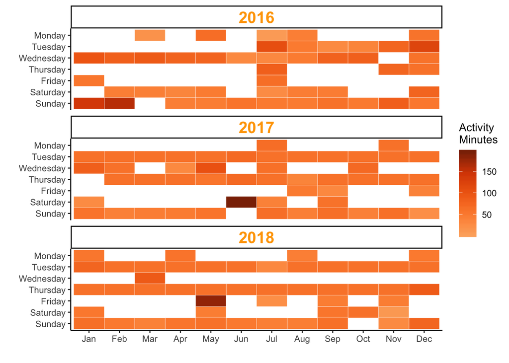

```r
calendar_heatmap <- runkeeper %>%
  select(Date,time_minutes,year) %>%
  filter(year >= year(now()) - 3) %>%
  mutate(
    week = week(as.Date(Date)),
    wday = wday(as.Date(Date), week_start = 1),
    month = month(as.Date(Date), label = TRUE, abbr = TRUE),
    day = weekdays(as.Date(Date))
  )

cols <- rev(rev(brewer.pal(7,"Oranges"))[1:5])

calendar_heatmap %>%
  ggplot(aes(month, reorder(day, -wday), fill = time_minutes)) +
  geom_tile(colour = "white") +
  scale_fill_gradientn('Activity \nMinutes', colours = cols) +
  facet_wrap(~ year, ncol = 1) +
  theme_classic() +
  theme(strip.text.x = element_text(size = 16, face = "bold", colour = "orange")) +
  ylab("") +
  xlab("")
```

## Screenshot

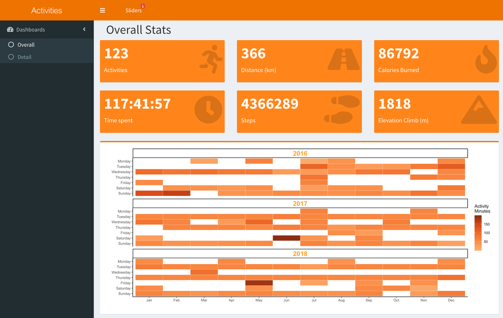

screenshot

Well wrap it up into a Shiny App which can be found on my GitHub.